# P5.4 - Tests

```python
# Import des librairies
import numpy as np                # linear algebra
import pandas as pd               # data frames
import seaborn as sns             # visualizations
import matplotlib.pyplot as plt   # visualizations

from scipy import stats
```

## Shapiro des variables

Shapiro-Wilk est un test de normalité.  
Il est indiqué pour le traitement d'échantillons réduits  
Il retourne les valeurs W = test statistique et p-value = seuil hypothèse loi normale

**Interprétation**

- Hypothèse nulle H0 : la variable suit une loi normale - seuil α = 5%
- Si p-value < α : l'hypothèse nulle est rejetée
- Si la p-value > α : on ne doit pas rejeter l'hypothèse nulle

### Cluster 1

```python
# rappel du cluster 1
cl1= pd.read_csv('data/cl1.csv', index_col = 0)
cl1.drop(['clust'], axis=1, inplace = True)
cl1.head(1)
```

| country | pop_2013 | pop_var | gdp_2013 | edb_2019 | food_kcal_cap_day | prot_g_cap_day | prot_ani_ratio | poultry_food_kg_cap_y | poultry_import_ratio |
| --- | --- | --- | --- | --- | --- | --- | --- | --- | --- |
| Australia | 23.343 | 107.844768 | 66301.306788 | 80.13 | 3278.0 | 106.26 | 67.466591 | 46.138029 | 1.578459 |

#### Test de Shapiro

```python
# Test Shapiro dans le cluster 1
for column in cl1:
    a = stats.shapiro(cl1[column])
    print(column, " : ", a)
```

```
pop_2013  :  (0.5173370242118835, 7.178522309914115e-07)
pop_var  :  (0.9604803919792175, 0.5818814039230347)
gdp_2013  :  (0.7875840067863464, 0.0007586915162391961)
edb_2019  :  (0.9630020260810852, 0.632750928401947)
food_kcal_cap_day  :  (0.9691357016563416, 0.7590471506118774)
prot_g_cap_day  :  (0.9158099889755249, 0.09469415247440338)
prot_ani_ratio  :  (0.98111492395401, 0.9544811248779297)
poultry_food_kg_cap_y  :  (0.8296353816986084, 0.003183872438967228)
poultry_import_ratio  :  (0.8877993822097778, 0.02942577376961708)
```

**hypothèses nulles rejetées cluster 1**

- **pop_2013** : 7.178522309914115e-07
- **gdp_2013** : 0.0007586915162391961
- **poultry_food_kg_cap_y** : 0.003183872438967228
- **poultry_import_ratio** : 0.02942577376961708

#### Représentations graphiques loi normale

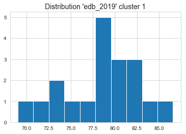

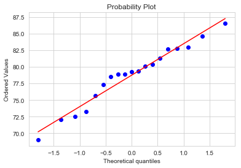

```python
# Variable dont la loi est normale 'edb_2019'

sns.set_style("whitegrid")
plt.subplot(111)
plt.hist(cl1['edb_2019'])
plt.title("Distribution 'edb_2019' cluster 1",size=14)

plt.savefig('img/p5.4_loi_normale_cl1a1.png', dpi=120, bbox_inches='tight')
plt.show()

plt.subplot(111)
stats.probplot(cl1['edb_2019'], dist="norm", plot=plt)
plt.savefig('img/p5.4_loi_normale_cl1a2.png', dpi=100, bbox_inches='tight')

plt.show()
plt.close()
```

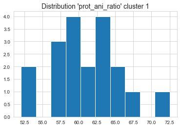

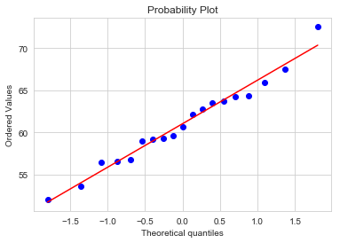

```python
# Variable dont la loi est normale 'prot_ani_ratio'

sns.set_style("whitegrid")
plt.subplot(111)
plt.hist(cl1['prot_ani_ratio'])
plt.title("Distribution 'prot_ani_ratio' cluster 1",size=14)

plt.savefig('img/p5.4_loi_normale_cl1b1.png', dpi=120, bbox_inches='tight')
plt.show()

plt.subplot(111)
stats.probplot(cl1['prot_ani_ratio'], dist="norm", plot=plt)
plt.savefig('img/p5.4_loi_normale_cl1b2.png', dpi=100, bbox_inches='tight')

plt.show()
plt.close()
```

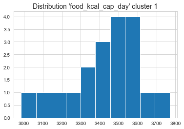

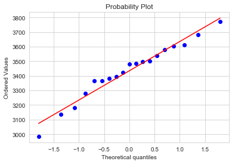

```python
# Variable dont la loi est normale 'food_kcal_cap_day'

sns.set_style("whitegrid")
plt.subplot(111)
plt.hist(cl1['food_kcal_cap_day'])
plt.title("Distribution 'food_kcal_cap_day' cluster 1",size=14)

plt.savefig('img/p5.4_loi_normale_cl1c1.png', dpi=120, bbox_inches='tight')
plt.show()

plt.subplot(111)
stats.probplot(cl1['food_kcal_cap_day'], dist="norm", plot=plt)
plt.savefig('img/p5.4_loi_normale_cl1c2.png', dpi=100, bbox_inches='tight')

plt.show()
plt.close()
```

### Cluster 5

```python
# rappel du cluster 5
cl5= pd.read_csv('data/cl5.csv', index_col = 0)
cl5.drop(['clust'], axis=1, inplace = True)
cl5.head(1)
```

| country | pop_2013 | pop_var | gdp_2013 | edb_2019 | food_kcal_cap_day | prot_g_cap_day | prot_ani_ratio | poultry_food_kg_cap_y | poultry_import_ratio |
| --- | --- | --- | --- | --- | --- | --- | --- | --- | --- |
| Afghanistan | 30.552 | 113.021604 | 681.033974 | 47.77 | 2087.0 | 58.26 | 20.957775 | 2.454831 | 64.0 |

#### Test de Shapiro

```python
# Test Shapiro dans le cluster 5
for column in cl5:
    a = stats.shapiro(cl5[column])
    print(column, " : ", a)
```

```
pop_2013  :  (0.5985195636749268, 6.778163642341684e-14)
pop_var  :  (0.9762810468673706, 0.1187627986073494)
gdp_2013  :  (0.8375800848007202, 3.1339180139866585e-08)
edb_2019  :  (0.9925829768180847, 0.915373682975769)
food_kcal_cap_day  :  (0.9687501192092896, 0.036934543401002884)
prot_g_cap_day  :  (0.9476842284202576, 0.0017485303105786443)
prot_ani_ratio  :  (0.9652774333953857, 0.021738886833190918)
poultry_food_kg_cap_y  :  (0.8646912574768066, 2.7289121362628066e-07)
poultry_import_ratio  :  (0.8019320964813232, 2.499110030029783e-09)
```

**hypothèses nulles rejetées cluster 5**

- **pop_2013** : 6.778163642341684e-14
- **gdp_2013** : 3.1339180139866585e-08
- **food_kcal_cap_day** : 0.036934543401002884
- **prot_g_cap_day** : 0.0017485303105786443
- **prot_ani_ratio** : 0.021738886833190918
- **poultry_food_kg_cap_y** : 2.7289121362628066e-07
- **poultry_import_ratio** : 2.499110030029783e-09

#### Représentations graphiques loi normale

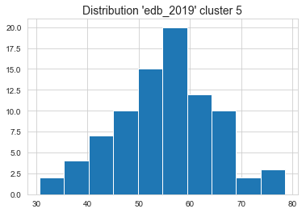

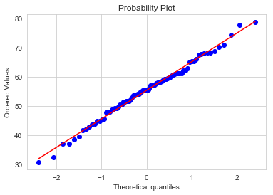

```python
# Variable dont la loi est normale 'edb_2019'

sns.set_style("whitegrid")
plt.subplot(111)
plt.hist(cl5['edb_2019'])
plt.title("Distribution 'edb_2019' cluster 5",size=14)

plt.savefig('img/p5.4_loi_normale_cl5a1.png', dpi=120, bbox_inches='tight')
plt.show()

plt.subplot(111)
stats.probplot(cl5['edb_2019'], dist="norm", plot=plt)
plt.savefig('img/p5.4_loi_normale_cl5a2.png', dpi=100, bbox_inches='tight')

plt.show()
plt.close()
```

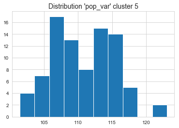

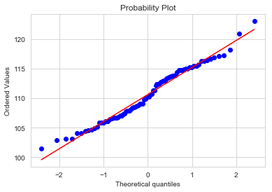

```python
# Variable dont la loi est normale 'pop_var'

sns.set_style("whitegrid")
plt.subplot(111)
plt.hist(cl5['pop_var'])
plt.title("Distribution 'pop_var' cluster 5",size=14)

plt.savefig('img/p5.4_loi_normale_cl5b1.png', dpi=120, bbox_inches='tight')
plt.show()

plt.subplot(111)
stats.probplot(cl5['pop_var'], dist="norm", plot=plt)
plt.savefig('img/p5.4_loi_normale_cl5b2.png', dpi=100, bbox_inches='tight')

plt.show()
plt.close()
```

## Tests de comparaison

```python
# Rappel du test de Shapiro sur Variable 'edb_2019' pour les clusters 1 et 5
shapcl1=stats.shapiro(cl1['edb_2019'])
shapcl5=stats.shapiro(cl5['edb_2019'])

print("p-value de 'edb_2019' (test de Shapiro) pour le cluster 1 =", shapcl1[1])
print("p-value de 'edb_2019' (test de Shapiro) pour le cluster 5 =", shapcl5[1])
```

```
p-value de 'edb_2019' (test de Shapiro) pour le cluster 1 = 0.632750928401947
p-value de 'edb_2019' (test de Shapiro) pour le cluster 5 = 0.915373682975769
```

### Test de Bartlett

- Comparation des variances avec le Test de Bartlett
- Hypothèse nulle (H0) = Egalité des variances de la variable 'edb_2019' sur les groupes 1 et 5

```python
b = stats.bartlett(cl1['edb_2019'], cl5['edb_2019'])
print("p-value (test de Bartlett) pour la variable 'edb_2019' =", b[1])
```

```
p-value (test de Bartlett) pour la variable 'edb_2019' = 0.0006119503668720269
```

**Hypothèse nulle rejetée**

- Les conditions de validité du ttest ne sot pas remplies
- Le Student test sur l'égalité des moyennes n'est pas nécéssaire
- Toutefois, nous terminons la démonstration

### t-test

```python
t = stats.ttest_ind(cl1['edb_2019'], cl5['edb_2019'], equal_var=True)
print("p-value t-test de la variable 'edb_2019' sur les clusters 1 et 5 =", t[1])
```

```
p-value t-test de la variable 'edb_2019' sur les clusters 1 et 5 = 2.2683141666114416e-17
```

**Hypothèse nulle rejetée**

- Différence significative de la moyenne, conditions non valides

### Test de Wilcoxon

Le test des rangs signés de Wilcoxon est une alternative **non-paramétrique** au test de Student pour des échantillons appariés.  
Il s'intéresse à un paramètre de position : la médiane, le but étant de tester s'il existe un changement sur la médiane.

Le test de Wilcoxon sur 2 samples est aussi appelé test Mann-Whitney

```python
from scipy.stats import mannwhitneyu

# Comparation des samples
stat, p = mannwhitneyu(cl1['edb_2019'], cl5['edb_2019'])
print('Statistics=%.3f, p=%.3f' % (stat, p))

# interprétation
alpha = 0.05
if p > alpha:
	print("Même distribution (l'hypothèse H0 ne peut pas être rejetée)")
else:
	print("Distribution différente (rejet de H0)")
```

```
Statistics=19.000, p=0.000
Distribution différente (rejet de H0)
```

**Hypothèse nulle rejetée**

Les distributions sont bien différentes